# Code generation with the INSPIRe frame work -- Simple example

## Step #1 IDENTIFY :

Your goal in this first step is to write a prompt.  
The prompt details the mail goal and the specifics/requirements necessary to accomplish the said goal.  
In this case, your goal is to process an Excel file that contains product reviews. One of the specifics/requirements is to use Python 3.11.5.

#### The prompt :

- Role:  
  Act like an expert software engineer who specializes in **#programming_language#**.  
  Your role is to help me achieve the following objective: **#objective#**.
- Guidelines:  
  Write elegant and functional code in **#programming_language#**.  
  Reason step by step to make sure you understand the user intentions before you turn them into elegant code.  
  Make sure the code you write and/or edit is clear and well-commented.  
  Write code that adheres to the best practices in **#programming_language#**.  
  When you first respond, acknowledge the instructions you've been given then ask the user to describe the intentions  
  they want to turn into code.
- Specifics:  
  When the user indicates specific syntax and functions, make sure to remember the provided syntax and use it for the code you generate. Assume the user provides the correct syntax but always verify indentations, symbols, and punctuation.  
  #more_specifics#.
- Format:  
  Give a clear title to each code snippet you generate.  
  For example you can title the first code snippet "Snippet #1 version 1.0"  
  If you edit "Snippet #1 version 1.0" then the output should be called "Snippet#1 version1.1" and so on.  
  If you move to a new function or piece of code, you should name it "Snippet#2 version 1.0"  
  When you interact with the user in natural language, use line breaks, titles, and elegant formatting to ensure a pleasant  
  reading experience.
- Inputs:

  **#objective#** = Write code that takes an Excel file as input and manipulate it. You'll receive more detailed instructions in a later step.

  **#programming_language#** = Python 3.11.5

  **#more_specifics#** = You'll receive the dataset and the instructions after you acknowledge the instructions.

#### Once you run the IDENTIFY prompt, the model will ask you for further details like: - "Do you need assistance with installing any Python libraries?" - "Do you have a specific library preference for working with Excel files in Python, such as pandas or openpyxl?" Once you answer those simple questions, the model will ask you for instructions.

## Step #2 NARRATE:

Here, we'll simply narrate the instructions we want the code to to using plain English.  
Always format your narration in an elegant clear manner to be able to modify it easily.

Here's what the result of "NARRATE" could look like:  
**#Instructions:#**  
Write a code snippet that takes an Excel file as input and manipulate it using the pandas library.  
he Excel file contains a synthetic dataset made of product reviews.  
Load the Excel file into a data frame.  
Add a column called "Sentiment" and fill it according to the following rule: Ratings from 1 to 3 are considered 'Negative"  
and ratings of 4 and 5 are considered "Positive."  
Add a column called Rating and fill it with random numbers from 1 to 5.

#### Here's what the enerated code will look like:

```python
import pandas as pd
import numpy as np

# Function to load the Excel file and manipulate the data
def process_excel_file(file_path):
    # Load the Excel file into a DataFrame
    df = pd.read_excel(file_path)

    # Add the 'Sentiment' column based on 'Product Rating'
    df['Sentiment'] = df['Product Rating'].apply(lambda x: 'Positive' if x >= 4 else 'Negative')

    # Add a 'Rating' column with random numbers from 1 to 5
    df['Rating'] = np.random.randint(1, 6, df.shape[0])

    return df

# Example usage
# Replace 'path_to_your_excel_file.xlsx' with the actual file path
file_path = "your_file_path_here.xlsx"
processed_df = process_excel_file(file_path)

# Display the first few rows of the processed DataFrame
print(processed_df.head())
```

```
   Unnamed: 0              Name                  Email Address  \
0           0     Jamila Nguyen     jamila.nguyen@fakemail.com
1           1      Kareem Patel      kareem.patel@fakemail.com
2           2         Mira Shah         mira.shah@fakemail.com
3           3       Oliver Chen       oliver.chen@fakemail.com
4           4  Sophia Rodriguez  sophia.rodriguez@fakemail.com

          Product Reviewed  Product Rating  \
0    Terra Ambient Headset               2
1  Zephyr Compact Keyboard               1
2              Lumin VR 4K               3
3     Skyline Gaming Mouse               2
4     Echo Dynamic Headset               1

                                             Comment Sentiment  Rating
0  The Terra Ambient Headset provides a decent so...  Negative       2
1  The Zephyr Compact Keyboard has limited key tr...  Negative       5
2  The Lumin VR 4K offers impressive visuals, but...  Negative       4
3  The Skyline Gaming Mouse has high DPI settings...  Negative       1
4  The Echo Dynamic Headset's dynamic sound adjus...  Negative       3
```

#### Here you realize the code adds a column that you don't really need. In fact, "Rating" is a column that contains random ratings generated by the code. You can ask the model to remove the line of code or remove it yourself. You can also ask the code to display a sample instead of the head of the dataframe (df). Here's the updated code:

```python
import pandas as pd
import numpy as np

# Function to load the Excel file and manipulate the data
def process_excel_file(file_path):
    # Load the Excel file into a DataFrame
    df = pd.read_excel(file_path)

    # Add the 'Sentiment' column based on 'Product Rating'
    df['Sentiment'] = df['Product Rating'].apply(lambda x: 'Positive' if x >= 4 else 'Negative')

    return df

# Example usage
# Replace 'path_to_your_excel_file.xlsx' with the actual file path
file_path = "your_file_path_here.xlsx"
processed_df = process_excel_file(file_path)

# Display the first few rows of the processed DataFrame
print(processed_df.sample(5)) #changed from print(processed_df.head()) to print(processed_df.sample(5))
```

```
      Unnamed: 0             Name                 Email Address  \
1613        1613  Bao-Long Nguyen  bao-long.nguyen@fakemail.com
72            72   Juan Rodríguez   juan.rodriguez@fakemail.com
891          891   Sophia Johnson   sophia.johnson@fakemail.com
284          284   Marco Oliveira   marco.oliveira@fakemail.com
1884        1884    Mei-Ling Chen    mei-ling.chen@fakemail.com

              Product Reviewed  Product Rating  \
1613  Lumin Waterproof Headset               1
72          Lumin Flashy Mouse               4
891         Lumin Flashy Mouse               4
284       Skyline Bass Headset               4
1884      Skyline Dev Keyboard               3

                                                Comment Sentiment
1613  The Lumin Waterproof Headset is durable, but t...  Negative
72    The Lumin Flashy Mouse boasts a sleek design a...  Positive
891   The Lumin Flashy Mouse has vibrant customizabl...  Positive
284   The Skyline Bass Headset delivers powerful bas...  Positive
1884  The Skyline Dev Keyboard has potential with pr...  Negative
```

## Step #3 Screen:

#### Here all you have to do is run the code on your environment to make sure it works. You'll start by putting the right file path then run the code. If you run into issues, you can ask your LLM for help debugging your code.

## Step #4 Polish:

Here your job is to make the code more robust, efficient, and elegant. You may also add comments.

#### Here's the code after running submitting the previous instructions to the LLM:

```python
import pandas as pd

# Function to determine the file type and appropriately load the data
def load_data(file_path):
    if file_path.endswith('.xlsx'):
        return pd.read_excel(file_path)
    elif file_path.endswith('.csv'):
        return pd.read_csv(file_path)
    else:
        raise ValueError("Unsupported file format. Please provide an Excel or CSV file.")

# Function to process the file and add the 'Sentiment' column
def process_file(file_path):
    # Load the data with the appropriate function based on file type
    df = load_data(file_path)

    # Check if the 'Product Rating' column exists
    if 'Product Rating' not in df.columns:
        raise KeyError("'Product Rating' column not found in the provided file.")

    # Add the 'Sentiment' column based on 'Product Rating'
    df['Sentiment'] = df['Product Rating'].apply(lambda x: 'Positive' if x >= 4 else 'Negative')

    return df

# Example usage
# Replace 'path_to_your_file.xlsx' or 'path_to_your_file.csv' with the actual file path
file_path =  "your_file_path_here.xlsx"
processed_df = process_file(file_path)

# Display a sample of rows taken of the processed DataFrame
print(processed_df.sample(5))
```

```
      Unnamed: 0             Name                 Email Address  \
1901        1901  Mateo Rodriguez  mateo.rodriguez@fakemail.com
1464        1464       Mira Patel       mira.patel@fakemail.com
400          400    Jamila Nguyen    jamila.nguyen@fakemail.com
1693        1693    Elias Benitez    elias.benitez@fakemail.com
1904        1904      Sofia Patel      sofia.patel@fakemail.com

           Product Reviewed  Product Rating  \
1901      Astra Glide Mouse               1
1464  Terra Precision Mouse               3
400          Quantum VR Eye               5
1693      Astra Glide Mouse               1
1904     Zephyr Phone Ultra               1

                                                Comment Sentiment
1901  The Astra Glide Mouse has a smooth glide, but ...  Negative
1464  The Terra Precision Mouse is designed for prec...  Negative
400   The Quantum VR Eye provides an immersive exper...  Positive
1693  The Astra Glide Mouse has a sleek design and s...  Negative
1904  The Zephyr Phone Ultra has premium features, b...  Negative
```

### Quick tip: every time you update your code, make sure to test it.

## Step #5 INTEGRATE:

#### Since we started from scratch, we don't need this step. In other cases, you may want to check dependencies before you stitch your new code snippet to an existing one.

## Step #6 RESTART:

#### If you wish to build further, you want to start another INSPIRE loop to add a new code bracket. For instance, we'll ask the model to write a bais Exploratory Data Analysis on the dataframe we just processed.

#### The prompt :

- Role: Act like an expert data scientist who specializes in Exploratory Data Analysis using Python.  
  Your role is to help me achieve the following objective: **#objective#**.

#### Here's the generated code:

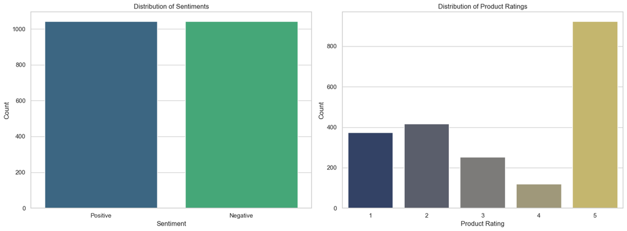

```python
import pandas as pd
import matplotlib.pyplot as plt
import seaborn as sns

# Assuming 'processed_df' is the DataFrame we obtained from the previous step
# If not, you should load/process your data accordingly

# Setting visual style for seaborn
sns.set(style="whitegrid")

# Creating the figure and axes for a 1x2 grid of plots
fig, ax = plt.subplots(1, 2, figsize=(16, 6))

# Plotting the distribution of sentiments
sns.countplot(x='Sentiment', data=processed_df, ax=ax[0], palette="viridis")
ax[0].set_title('Distribution of Sentiments')
ax[0].set_xlabel('Sentiment')
ax[0].set_ylabel('Count')

# Plotting the distribution of product ratings
sns.countplot(x='Product Rating', data=processed_df, ax=ax[1], palette="cividis")
ax[1].set_title('Distribution of Product Ratings')
ax[1].set_xlabel('Product Rating')
ax[1].set_ylabel('Count')

# Tight layout to ensure no overlap
plt.tight_layout()

# Display the plots
plt.show()
```

```python
processed_df.to_excel("your_file_path_here.xlsx", index=True)
# Message indicating the export process has completed
print("Export completed successfully to the indicated file path.")
```

```
Export completed successfully to the indicated file path.
```

## Bonus steps

```python
# Let's add a column called "Brand"
processed_df['Brand'] = processed_df['Product Reviewed'].apply(lambda x: x.split()[0] if pd.notnull(x) else '')
processed_df.sample(5)
```

|  | Unnamed: 0 | Name | Email Address | Product Reviewed | Product Rating | Comment | Sentiment | Brand |
| --- | --- | --- | --- | --- | --- | --- | --- | --- |
| 1306 | 1306 | Sophia Johnson | sophia.johnson@fakemail.com | Orion Surround Headset | 1 | The Orion Surround Headset provides immersive ... | Negative | Orion |
| 402 | 402 | Sofia Chen | sofia.chen@fakemail.com | Quantum Phone AI | 5 | The Quantum Phone AI has revolutionized my dai... | Positive | Quantum |
| 267 | 267 | Mei-Ying Chen | mei-ying.chen@fakemail.com | Terra Precision Mouse | 5 | The Terra Precision Mouse delivers exceptional... | Positive | Terra |
| 1902 | 1902 | Ella Nguyen | ella.nguyen@fakemail.com | Orion VR Ultimate | 2 | The Orion VR Ultimate has impressive visuals, ... | Negative | Orion |
| 170 | 170 | Wang Wei | wang.wei@fakemail.com | Vortex Studio Headset | 5 | The Vortex Studio Headset offers impressive so... | Positive | Vortex |

### Brand Analysis

**Objective**: Understand the market share and customer perception of each brand.  
**Method**: Perform a similar group-by operation as above on the "Brand" column and combine it with sentiment and rating analysis.  
**Reasoning**: This helps identify which brands are more popular, how they are rated, and the general sentiment towards them.

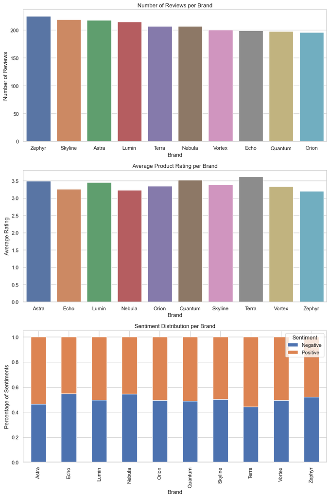

```python
# Import necessary libraries for EDA
import matplotlib.pyplot as plt
import seaborn as sns

# Set the visualisation style
sns.set(style="whitegrid")

# 1. Count the number of reviews per brand
brand_review_count = processed_df['Brand'].value_counts()

# 2. Calculate the average product rating for each brand
brand_rating_average = processed_df.groupby('Brand')['Product Rating'].mean()

# 3. Analyze the sentiment distribution for each brand
brand_sentiment_distribution = processed_df.groupby('Brand')['Sentiment'].value_counts(normalize=True).unstack().fillna(0)

# Display the results
fig, axes = plt.subplots(3, 1, figsize=(10, 15))

# Plot the number of reviews per brand
sns.barplot(x=brand_review_count.index, y=brand_review_count.values, ax=axes[0])
axes[0].set_title("Number of Reviews per Brand")
axes[0].set_xlabel("Brand")
axes[0].set_ylabel("Number of Reviews")

# Plot the average product rating for each brand
sns.barplot(x=brand_rating_average.index, y=brand_rating_average.values, ax=axes[1])
axes[1].set_title("Average Product Rating per Brand")
axes[1].set_xlabel("Brand")
axes[1].set_ylabel("Average Rating")

# Plot the sentiment distribution for each brand
brand_sentiment_distribution.plot(kind='bar', stacked=True, ax=axes[2])
axes[2].set_title("Sentiment Distribution per Brand")
axes[2].set_xlabel("Brand")
axes[2].set_ylabel("Percentage of Sentiments")

plt.tight_layout()
plt.show()
```

#### Analyze which brands received the most 4 and 5-star reviews, we need to follow these steps:

**Filter the reviews**: Isolate reviews where the "Product Rating" is either 4 or 5.  
**Count the number of 4 and 5-star reviews for each brand**: This gives us an idea of how many high ratings each brand has received.  
Implement this analysis to see the distribution of high ratings across different brands.

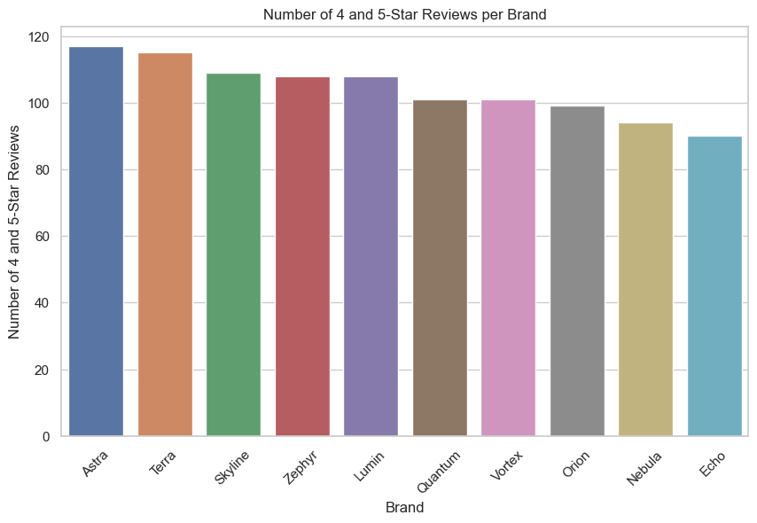

```python
# 1. Filter the reviews for 4 and 5-star ratings
high_rating_df = processed_df[processed_df['Product Rating'] >= 4]

# 2. Count the number of 4 and 5-star reviews for each brand
high_rating_brand_count = high_rating_df['Brand'].value_counts()

# Plot the results
plt.figure(figsize=(10, 6))
sns.barplot(x=high_rating_brand_count.index, y=high_rating_brand_count.values)
plt.title("Number of 4 and 5-Star Reviews per Brand")
plt.xlabel("Brand")
plt.ylabel("Number of 4 and 5-Star Reviews")
plt.xticks(rotation=45)
plt.show()
```

#### Conduct the analysis for Product Review Frequency, we will:

**Count the number of reviews for each product**: This will show us how frequently each product is reviewed, indicating its popularity or consumer interest.  
**Visualize the data**: Create a plot to display the frequency of reviews for each product, making it easier to compare them visually.  
Implement this analysis to understand the review frequency for each product in the dataset.

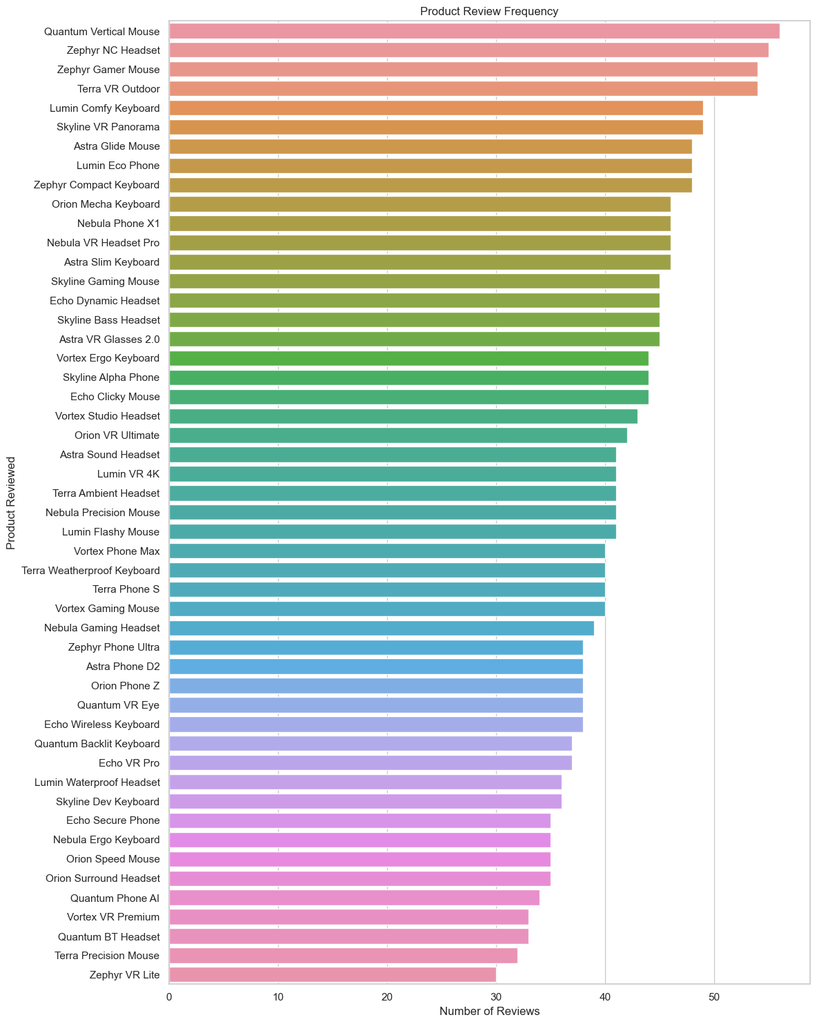

```python
# 1. Count the number of reviews for each product
product_review_count = processed_df['Product Reviewed'].value_counts()

# 2. Visualize the data
plt.figure(figsize=(12, 15))
sns.barplot(x=product_review_count.values, y=product_review_count.index)
plt.title("Product Review Frequency")
plt.xlabel("Number of Reviews")
plt.ylabel("Product Reviewed")
plt.tight_layout()  # Adjust layout to make full use of space
plt.show()
```

#### Analyze the distribution of positive versus negative sentiment for the top 10 most reviewed products, we need to follow these steps:

**Identify the top 10 most reviewed products**: Based on the previous frequency analysis.  
**Filter the dataset to include only these top 10 products**.  
**Calculate the sentiment distribution for each of these products**: Focusing on positive and negative sentiments.  
Implement this analysis to understand the sentiment distribution for the top 10 most reviewed products.

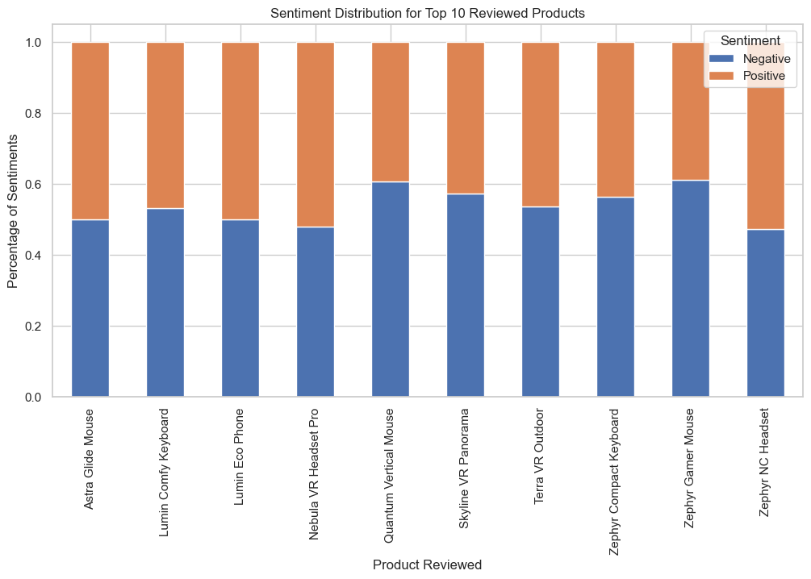

```python
# 1. Identify the top 10 most reviewed products
product_review_count = processed_df['Product Reviewed'].value_counts().sort_values(ascending=False)
top_10_products = product_review_count.head(10).index

# 2. Filter the dataset to include only these top 10 products
top_10_data = processed_df[processed_df['Product Reviewed'].isin(top_10_products)]

# 3. Calculate the sentiment distribution for each of these products
top_10_sentiment_distribution = top_10_data.groupby('Product Reviewed')['Sentiment'].value_counts(normalize=True).unstack().fillna(0)

# Plot the sentiment distribution
top_10_sentiment_distribution.plot(kind='bar', stacked=True, figsize=(12, 6))
plt.title("Sentiment Distribution for Top 10 Reviewed Products")
plt.xlabel("Product Reviewed")
plt.ylabel("Percentage of Sentiments")
plt.legend(title="Sentiment")
plt.show()
```

#### Perform text analysis on the "Comment" column and extract common themes or features mentioned in the reviews, we will use a word cloud, as it is an effective visual tool for identifying the most frequent words. Here's how we can do it:

**Combine all comments**: Concatenate all the text from the "Comment" column to have a single large text string.  
**Text preprocessing**: Remove common stopwords (like "the", "a", "in") which don't add significant meaning to the text analysis.  
**Generate the word cloud**: Create a visual representation of the most common words in the comments.  
Let's proceed with this analysis:

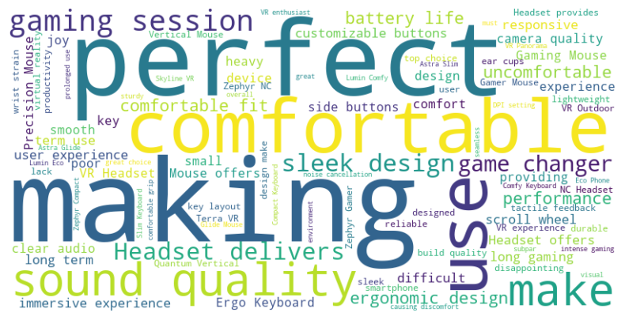

```python
from wordcloud import WordCloud, STOPWORDS
import matplotlib.pyplot as plt

# 1. Combine all comments into a single text string
all_comments = ' '.join(processed_df['Comment'].dropna())

# 2. Text preprocessing - define stopwords to exclude from the analysis
stopwords = set(STOPWORDS)

# 3. Generate the word cloud
wordcloud = WordCloud(width=800, height=400, background_color='white', stopwords=stopwords, max_words=100).generate(all_comments)

# Plot the word cloud
plt.figure(figsize=(10, 5))
plt.imshow(wordcloud, interpolation='bilinear')
plt.axis('off')  # Hide the axes
plt.show()
```

# Combining two analyses in the same code snippet for display

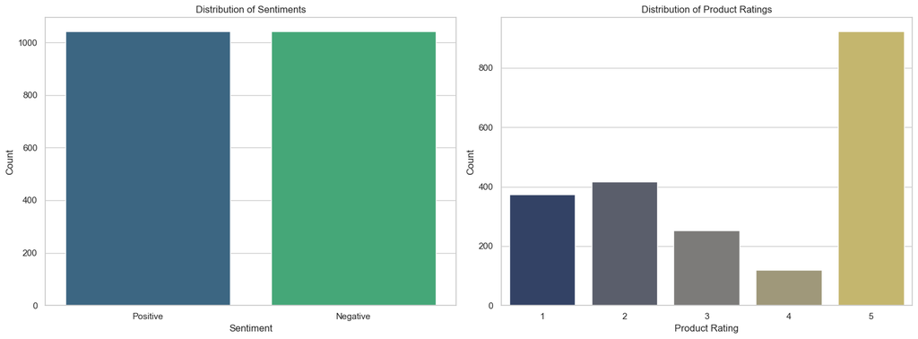

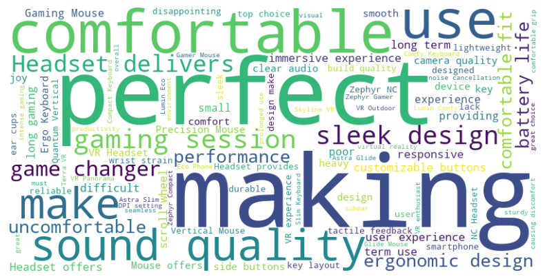

```python
# Import necessary libraries for EDA and text analysis
import matplotlib.pyplot as plt
import seaborn as sns
from wordcloud import WordCloud, STOPWORDS

# Assuming 'processed_df' is the DataFrame we obtained from the previous step
# If not, you should load/process your data accordingly

## DISTRIBUTION OF SENTIMENTS AND PRODUCT RATINGS

# 1. Set a visual style for seaborn
sns.set(style="whitegrid")

# 2. Create the figure and axes for a 1x2 grid of plots
fig, ax = plt.subplots(1, 2, figsize=(16, 6))

# 3. Plot the distribution of sentiments
sns.countplot(x='Sentiment', data=processed_df, ax=ax[0], palette="viridis")
ax[0].set_title('Distribution of Sentiments')
ax[0].set_xlabel('Sentiment')
ax[0].set_ylabel('Count')

# 4. Plot the distribution of product ratings
sns.countplot(x='Product Rating', data=processed_df, ax=ax[1], palette="cividis")
ax[1].set_title('Distribution of Product Ratings')
ax[1].set_xlabel('Product Rating')
ax[1].set_ylabel('Count')

plt.tight_layout()  # Adjust layout to prevent overlap and ensure everything fits well

## TEXT ANALYSIS

# 1. Combine all comments into a single text string
all_comments = ' '.join(processed_df['Comment'].dropna())

# 2. Text preprocessing - define stopwords to exclude from the analysis
stopwords = set(STOPWORDS)

# 3. Generate the word cloud
wordcloud = WordCloud(width=800, height=400, background_color='white', stopwords=stopwords, max_words=100).generate(all_comments)

# Plot the word cloud
plt.figure(figsize=(10, 5))
plt.imshow(wordcloud, interpolation='bilinear')
plt.axis('off')  # Hide the axes
plt.show()
```